# QuickSort

Prof. Juliano Foleis

## Partition

O algoritmo `PARTITION` usado no `QuickSort` rearranja os elementos de um vetor V[p,…,r], tal que $p\leq r$ de forma que

$$\forall k(p \leq k < q \rightarrow v[k] \leq v[q])\\
\land \\
\forall k(q+1 \leq k \leq r \rightarrow v[k] > v[q])$$

Graficamente,

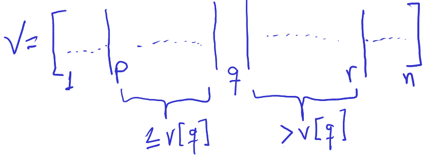

## PARITITON (Lomuto)

Existem vários algoritmos possíveis que estabelecem as propriedades de `PARTITION`.

Vamos estudar a implementação Lomuto:

```
PARTITION(V, p, r)
  x = V[r]
  i = p - 1
  FOR j = p TO r-1 DO
      IF V[j] <= x THEN
          i = i + 1
          troca V[i] e V[j]
      END IF
  END FOR
  troca V[i+1] e V[r]
  RETURN i+1
```

**Exercício:** Prove que este algoritmo tem custo $\Theta(n)$ tal que $n=r-p+1$.

## Corretude do `PARTITION`

Este algoritmo está correto somente se ao final da execução os elementos de um vetor V[p,…,r], tal que $p\leq r$, respeitarem as seguintes propriedades:

$$\forall k(p \leq k \leq i \rightarrow v[k] \leq v[i+1]) \land \forall k(i+1 < k \leq r \rightarrow v[k] > v[i+1])$$

**Invariante:**

No início de cada iteração do laço `FOR` das linhas 4–9, para qualquer índice $k$,

1. Se $p \leq k \leq i$, então $V[k] \leq x$
2. Se $i+1 \leq k \leq j - 1$, então $V[k] > x$
3. Se $k=r$, então $V[k] = x$

## Corretude do `PARTITION`

```
PARTITION(V, p, r)
  x = V[r]
  i = p - 1
  FOR j = p TO r-1 DO
      IF V[j] <= x THEN
          i = i + 1
          troca V[i] e V[j]
      END IF
  END FOR
  troca V[i+1] e V[r]
  RETURN i+1
```

**Invariante:** No início de cada iteração do laço `FOR` das linhas 4–9, para qualquer índice $k$,

1. Se $p \leq k \leq i$, então $V[k] \leq x$
2. Se $i+1 \leq k \leq j - 1$, então $V[k] > x$
3. Se $k=r$, então $V[k] = x$

**Graficamente:**

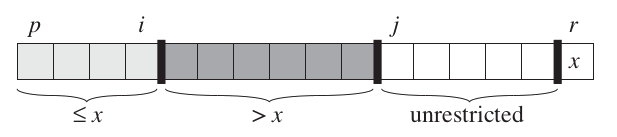

## Corretude do `PARTITION`

```
PARTITION(V, p, r)
  x = V[r]
  i = p - 1
  FOR j = p TO r-1 DO
      IF V[j] <= x THEN
          i = i + 1
          troca V[i] e V[j]
      END IF
  END FOR
  troca V[i+1] e V[r]
  RETURN i+1
```

**Invariante:** No início de cada iteração do laço `FOR` das linhas 4–9, para qualquer índice $k$,

1. Se $p \leq k \leq i$, então $V[k] \leq x$
2. Se $i+1 \leq k \leq j - 1$, então $V[k] > x$
3. Se $k=r$, então $V[k] = x$

**Inicialização:** Antes da primeira iteração, i=p-1, j=p e x=V[r]. Vamos verificar as proposições da invariante:

**Proposição 1:** Pode ser escrita como $\forall k(p \leq k \leq i \rightarrow V[k] \leq x)$.

$$\begin{align}
\forall k(p \leq k \leq i & \rightarrow V[k] \leq x)\\
\forall k(p \leq k \leq (p-1) & \rightarrow V[k] \leq x) \text{ (substituindo i=p-1)}
\end{align}$$

Como o domínio de $k$ é vazio uma vez que $((p-1)-p+1) = 0$, então, pela definição do quantificador universal, a proposição é verdadeira. Em outras palavras, como não há elementos no vetor v[p..p-1] não há como violar a proposição.

## Corretude do `PARTITION`

```
PARTITION(V, p, r)
  x = V[r]
  i = p - 1
  FOR j = p TO r-1 DO
      IF V[j] <= x THEN
          i = i + 1
          troca V[i] e V[j]
      END IF
  END FOR
  troca V[i+1] e V[r]
  RETURN i+1
```

**Invariante:** No início de cada iteração do laço `FOR` das linhas 4–9, para qualquer índice $k$,

1. Se $p \leq k \leq i$, então $V[k] \leq x$
2. Se $i+1 \leq k \leq j - 1$, então $V[k] > x$
3. Se $k=r$, então $V[k] = x$

**Inicialização (cont.):** Antes da primeira iteração, i=p-1, j=p e x=V[r].

**Proposição 2:** Pode ser escrita como $\forall k(i+1 \leq k \leq j - 1 \rightarrow V[k] > x)$.

$$\begin{align}
\forall k(i+1 \leq k \leq j - 1 & \rightarrow V[k] > x)\\
\forall k((p-1)+1 \leq k \leq p - 1 & \rightarrow V[k] > x) \text{ (substituindo $i=p-1$ e $j=p$)}\\
\forall k(p \leq k \leq p - 1 & \rightarrow V[k] > x)
\end{align}$$

Como o domínio de $k$ é vazio uma vez que $((p-1)-p+1) = 0$, então, pela definição do quantificador universal, a proposição é verdadeira. Em outras palavras, como não há elementos no vetor v[p..p-1] não há como violar a proposição.

## Corretude do `PARTITION`

```
PARTITION(V, p, r)
  x = V[r]
  i = p - 1
  FOR j = p TO r-1 DO
      IF V[j] <= x THEN
          i = i + 1
          troca V[i] e V[j]
      END IF
  END FOR
  troca V[i+1] e V[r]
  RETURN i+1
```

**Invariante:** No início de cada iteração do laço `FOR` das linhas 4–9, para qualquer índice $k$,

1. Se $p \leq k \leq i$, então $V[k] \leq x$
2. Se $i+1 \leq k \leq j - 1$, então $V[k] > x$
3. Se $k=r$, então $V[k] = x$

**Inicialização (cont.):** Antes da primeira iteração, i=p-1, j=p e x=V[r].

**Proposição 3:** A proposição diz que p/ $k=r$, V[k] = x. Substituindo $k=r$, temos que V[r] = x, que é a atribuição realizada na linha 1. Portanto, a proposição 3 é verdadeira antes da primeira iteração.

Como mostramos que as proposições 1, 2 e 3 são verdadeiras antes da primeira iteração do laço, a invariante é verdadeira após a inicialização.

## Corretude do `PARTITION`

```
PARTITION(V, p, r)
  x = V[r]
  i = p - 1
  FOR j = p TO r-1 DO
      IF V[j] <= x THEN
          i = i + 1
          troca V[i] e V[j]
      END IF
  END FOR
  troca V[i+1] e V[r]
  RETURN i+1
```

**Invariante:** No início de cada iteração do laço `FOR` das linhas 4–9, para qualquer índice $k$,

1. Se $p \leq k \leq i$, então $V[k] \leq x$
2. Se $i+1 \leq k \leq j - 1$, então $V[k] > x$
3. Se $k=r$, então $V[k] = x$

**Manutenção:** Consideramos 2 casos: o caso que a condicional da linha 5 é verdadeira e o caso que é falsa. Quando a condicional é falsa ($V[j]>x$), temos a seguinte situação:

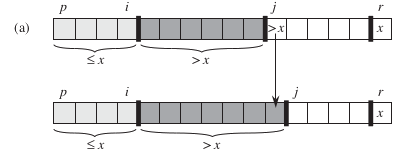

## Corretude do `PARTITION`

```
PARTITION(V, p, r)
  x = V[r]
  i = p - 1
  FOR j = p TO r-1 DO
      IF V[j] <= x THEN
          i = i + 1
          troca V[i] e V[j]
      END IF
  END FOR
  troca V[i+1] e V[r]
  RETURN i+1
```

**Invariante:** No início de cada iteração do laço `FOR` das linhas 4–9, para qualquer índice $k$,

1. Se $p \leq k \leq i$, então $V[k] \leq x$
2. Se $i+1 \leq k \leq j - 1$, então $V[k] > x$
3. Se $k=r$, então $V[k] = x$

**Manutenção (cont.):** **No caso que a condicional da linha 5 é falsa**, sabemos que $V[j]>x$ e que não há alteração nas variáveis $i$, $j$ e em qualquer elemento de V[p..r]. Isto é verdade pois a única instrução que é executada é o incremento de $j$.

**Proposição 1:** No início da iteração supomos que a invariante é verdadeira, e portanto esta proposição também é. Como $i$ não é alterado e não há troca dos elementos que estão entre as posições $p$ e $i$, a proposição 1 é mantida verdadeira.

## Corretude do `PARTITION`

```
PARTITION(V, p, r)
  x = V[r]
  i = p - 1
  FOR j = p TO r-1 DO
      IF V[j] <= x THEN
          i = i + 1
          troca V[i] e V[j]
      END IF
  END FOR
  troca V[i+1] e V[r]
  RETURN i+1
```

**Invariante:** No início de cada iteração do laço `FOR` das linhas 4–9, para qualquer índice $k$,

1. Se $p \leq k \leq i$, então $V[k] \leq x$
2. Se $i+1 \leq k \leq j - 1$, então $V[k] > x$
3. Se $k=r$, então $V[k] = x$

**Manutenção (cont.):** **No caso que a condicional da linha 5 é falsa**, sabemos que $V[j]>x$ e que não há alteração nas variáveis $i$, $j$ e em qualquer elemento de V[p..r]. Isto é verdade pois a única instrução que é executada é o incremento de $j$.

**Proposição 2:**

$$\begin{align}
\forall k(i+1 \leq k \leq & \, j - 1 \rightarrow V[k] > x) \text{ (invariante de laço)}\\
\forall k(i+1 \leq k \leq & \, j - 1 \rightarrow V[k] > x) \land V[j] > x \text{ (como $V[j]>x$)}\\
\forall k(i+1 \leq k \leq & \, \mathbf{j} \rightarrow V[k] > x) \text{ (def. de $\forall$)}\\
\forall k(i+1 \leq k \leq & \, \mathbf{j}-1 \rightarrow V[k] > x) \text{ (após j++ do FOR)}\\
\end{align}$$

Conforme mostrado acima, a invariante é mantida verdadeira antes da próxima iteração.

## Corretude do `PARTITION`

```
PARTITION(V, p, r)
  x = V[r]
  i = p - 1
  FOR j = p TO r-1 DO
      IF V[j] <= x THEN
          i = i + 1
          troca V[i] e V[j]
      END IF
  END FOR
  troca V[i+1] e V[r]
  RETURN i+1
```

**Invariante:** No início de cada iteração do laço `FOR` das linhas 4–9, para qualquer índice $k$,

1. Se $p \leq k \leq i$, então $V[k] \leq x$
2. Se $i+1 \leq k \leq j - 1$, então $V[k] > x$
3. Se $k=r$, então $V[k] = x$

**Manutenção (cont.):** **No caso que a condicional da linha 5 é falsa**, sabemos que $V[j]>x$ e que não há alteração nas variáveis $i$, $j$ e em qualquer elemento de V[p..r]. Isto é verdade pois a única instrução que é executada é o incremento de $j$.

**Proposição 3:** Pela invariante de laço, sabemos que no início da iteração p/ $k=r$, V[k] = x. Como $r$ não é usado para indexar o vetor e nenhum elemento de V[p..r] é alterado neste caso, não é possível que $V[k] \neq x$.

Como mostramos que as proposições 1, 2 e 3 são mantidas verdadeiras após a execução do laço quando a condicional da linha 5 é falsa, a invariante é mantida verdadeira neste caso. Vamos verificar o que acontece quando a condicional da linha 5 é verdadeira.

## Corretude do `PARTITION`

```
PARTITION(V, p, r)
  x = V[r]
  i = p - 1
  FOR j = p TO r-1 DO
      IF V[j] <= x THEN
          i = i + 1
          troca V[i] e V[j]
      END IF
  END FOR
  troca V[i+1] e V[r]
  RETURN i+1
```

**Invariante:** No início de cada iteração do laço `FOR` das linhas 4–9, para qualquer índice $k$,

1. Se $p \leq k \leq i$, então $V[k] \leq x$
2. Se $i+1 \leq k \leq j - 1$, então $V[k] > x$
3. Se $k=r$, então $V[k] = x$

**Manutenção (cont.):** Quando a condicional da linha 5 é verdadeira ($V[j]\leq x$), temos a seguinte situação:

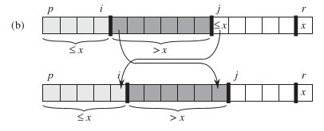

## Corretude do `PARTITION`

```
PARTITION(V, p, r)
  x = V[r]
  i = p - 1
  FOR j = p TO r-1 DO
      IF V[j] <= x THEN
          i = i + 1
          troca V[i] e V[j]
      END IF
  END FOR
  troca V[i+1] e V[r]
  RETURN i+1
```

**Invariante:** No início de cada iteração do laço `FOR` das linhas 4–9, para qualquer índice $k$,

1. Se $p \leq k \leq i$, então $V[k] \leq x$
2. Se $i+1 \leq k \leq j - 1$, então $V[k] > x$
3. Se $k=r$, então $V[k] = x$

**Manutenção (cont.):** **No caso que a condicional da linha 5 é verdadeira**, sabemos que $V[j] \leq x$.

**Proposição 1:**

$$\begin{align}
\forall k(p \leq k \leq i & \rightarrow V[k] \leq x) \text{ (invariante de laço)}\\
\forall k(p \leq k \leq i-1 & \rightarrow V[k] \leq x) \land (V[i] > x) \land (V[j] \leq x) \text{ (após a l.6, pelo if e prop. 2)}\\
\forall k(p \leq k \leq i-1 & \rightarrow V[k] \leq x) \land (V[i] \leq x) \land (V[j] > x) \text{ (após a l.7)}\\
\forall k(p \leq k \leq i-1 & \rightarrow V[k] \leq x) \land (V[i] \leq x) \text{ (eq. simplificação)}\\
\forall k(p \leq k \leq i & \rightarrow V[k] \leq x) \text{ (def. $\forall$)}\\
\end{align}$$

Pelo argumento acima, a proposição é mantida verdadeira.

## Corretude do `PARTITION`

```
PARTITION(V, p, r)
  x = V[r]
  i = p - 1
  FOR j = p TO r-1 DO
      IF V[j] <= x THEN
          i = i + 1
          troca V[i] e V[j]
      END IF
  END FOR
  troca V[i+1] e V[r]
  RETURN i+1
```

**Invariante:** No início de cada iteração do laço `FOR` das linhas 4–9, para qualquer índice $k$,

1. Se $p \leq k \leq i$, então $V[k] \leq x$
2. Se $i+1 \leq k \leq j - 1$, então $V[k] > x$
3. Se $k=r$, então $V[k] = x$

**Manutenção (cont.):** **No caso que a condicional da linha 5 é verdadeira**, sabemos que $V[j] \leq x$.

**Proposição 2:**

$$\begin{align}
\forall k(i+1 \leq k \leq & \, j - 1 \rightarrow V[k] > x) \text{ (invariante de laço)}\\
\forall k(i \leq k \leq & \, j - 1 \rightarrow V[k] > x) \land V[j] \leq x \text{ (após a l.6 e pelo if)}\\
\forall k(i+1 \leq k \leq & \, j - 1 \rightarrow V[k] > x) \land (V[j] > x) \land (V[i] \leq x) \text{ (após a linha 7)}\\
\forall k(i+1 \leq k \leq & \, j - 1 \rightarrow V[k] > x) \land (V[j] > x) \text{ (eq. simplificação)}\\
\forall k(i+1 \leq k \leq & \, j \rightarrow V[k] > x) \text{ (def. de $\forall$)}\\
\forall k(i+1 \leq k \leq & \, j - 1 \rightarrow V[k] > x) \text{ (após j++ do FOR)}
\end{align}$$

Conforme mostrado acima, a invariante é mantida verdadeira antes da próxima iteração.

## Corretude do `PARTITION`

```
PARTITION(V, p, r)
  x = V[r]
  i = p - 1
  FOR j = p TO r-1 DO
      IF V[j] <= x THEN
          i = i + 1
          troca V[i] e V[j]
      END IF
  END FOR
  troca V[i+1] e V[r]
  RETURN i+1
```

**Invariante:** No início de cada iteração do laço `FOR` das linhas 4–9, para qualquer índice $k$,

1. Se $p \leq k \leq i$, então $V[k] \leq x$
2. Se $i+1 \leq k \leq j - 1$, então $V[k] > x$
3. Se $k=r$, então $V[k] = x$

**Manutenção (cont.):** **No caso que a condicional da linha 5 é verdadeira**, sabemos que $V[j] \leq x$.

**Proposição 3:** Pela invariante de laço, sabemos que no início da iteração p/ $k=r$, V[k] = x. $r$ não é usado para indexar o vetor, e portanto a $V[r]$ não é alterado diretamente. Além disto, o vetor é alterado apenas na linha 7, usando $i$ e $j$ como índices, que nunca recebem o valor $r$, uma vez que $j$ só varia de $p$ a $r-1$ e $i$ é sempre menor que $j$. Desta forma, não é possível que $V[k] \neq x$.

Como mostramos que as proposições 1, 2 e 3 são mantidas verdadeiras após a execução do laço quando a condicional da linha 5 é verdadeira, a invariante é mantida verdadeira neste caso. Como mostramos que a invariante é mantida em ambos casos, podemos concluir que a invariante se mantém entre duas iterações quaisquer.

## Corretude do `PARTITION`

```
PARTITION(V, p, r)
  x = V[r]
  i = p - 1
  FOR j = p TO r-1 DO
      IF V[j] <= x THEN
          i = i + 1
          troca V[i] e V[j]
      END IF
  END FOR
  troca V[i+1] e V[r]
  RETURN i+1
```

**Invariante:** No início de cada iteração do laço `FOR` das linhas 4–9, para qualquer índice $k$,

1. Se $p \leq k \leq i$, então $V[k] \leq x$
2. Se $i+1 \leq k \leq j - 1$, então $V[k] > x$
3. Se $k=r$, então $V[k] = x$

**Término:** No término, temos $j=r$. Substituindo na invariante, temos:

1. Se $p \leq k \leq i$, então $V[k] \leq x$
2. Se $i+1 \leq k \leq r - 1$, então $V[k] > x$
3. Se $k=r$, então $V[k] = x$

Após a troca da linha 10 temos:

1. Se $p \leq k \leq i$, então $V[k] \leq V[i+1]\,$ (pois V[r]=x (pela 3ª prop.) foi trocado com V[i+1])
2. Se $i+1 < k \leq r$, então $V[k] > V[i+1]\,$ (pois V[r]=x (pela 3ª prop.) foi trocado com V[i+1])

## Corretude do `PARTITION`

**Término (cont.):**

1. Se $p \leq k \leq i$, então $V[k] \leq V[i+1]\,$
2. Se $i+1 < k \leq r$, então $V[k] > V[i+1]\,$

Considerando $q=i+1$, estas duas proposições descrevem exatamente as propriedades que queríamos assegurar ao vetor pelo algoritmo `PARTITION`. Relembrando a figura apresentada no início:

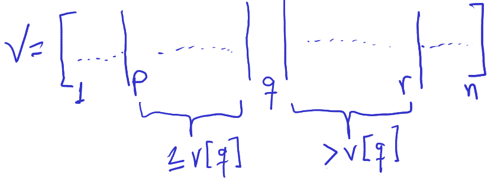

Portanto, o algoritmo está correto.

## QuickSort

```
QUICKSORT(V, p, r)
  IF p < r THEN
    q = PARTITION(V, p, r)
    QUICKSORT(V, p, q-1)
    QUICKSORT(V, q+1, r)
  END IF
```

Baseado em divisão e conquista, o algoritmo para ordenar $V[p,\dots,r]$ pode ser descrito por:

- *DIVISÃO* – Particionar o vetor $V[p,\dots,r]$ em dois subvetores potencialmente vazios $V[p,\dots,q-1]$ e $V[q+1,\dots,r]$ de forma que os elementos $V[p,\dots,q-1]$ sejam menores ou iguais a $V[q]$, que, por sua vez, é menor ou igual a todos os elementos em $V[q+1,\dots,r]$.
- *CONQUISTA* – Ordenar $A[p, \dots, q-1]$ e $A[q+1, \dots, r]$ recursivamente, usando `QUICKSORT`.
- *COMBINAÇÃO* – Como os subvetores $A[p, \dots, q-1]$ e $A[q+1, \dots, r]$ já estão ordenados, trabalho adicional não é necessário para combiná-los: o subvetor $A[p, \dots, r]$ está ordenado.

## Desempenho do QuickSort

O desempenho do `QUICKSORT` depende do balanceamento obtido por `PARTITION`, que depende da escolha do pivô e da relação dos valores dos elementos. Se o particionamento é balanceado, ou seja, o pivô “divide” o subvetor em 2 partições com quantidades praticamente iguais de elementos, o algoritmo possui complexidade assintótica idêntica ao `HEAPSORT` e `MERGESORT`.

Caso contrário, a complexidade assintótica é a mesma que do ineficiente `BUBBLESORT`. Primeiramente, analisamos informalmente o desempenho do `QUICKSORT` em relação ao balanceamento do particionamento.

## Custo do QuickSort no Pior Caso

O pior caso do `QUICKSORT` acontece quando `PARTITION` produz dois subproblemas: um com $0$ elementos e outro com $n-1$ elementos em todas as chamadas recursivas em `QUICKSORT`. Como o particionamento tem custo $\Theta(n)$ e $T(0)$ tem custo constante, a recorrência neste caso é:

$$\begin{align*}
T(n) & = T(n-1) + T(0) + \Theta(n)\\
& = T(n-1) + \Theta(n)
\end{align*}$$

Intuitivamente, ao somarmos o custo de todos os níveis da recursão teríamos $n$ níveis, cada um com um elemento a menos que o nível anterior de custo $\Theta(n)$ teríamos uma série aritmética ($cn + c(n-1) + c(n-2) + \dots + c1$), que é $\Theta(n^2)$. Desta forma, se o particionamento for totalmente desbalanceado em todo nível da recursão, o tempo de execução é $\Theta(n^2)$, que não é melhor que o `INSERTIONSORT`, por exemplo. Além disto, o pior caso ocorre quando o vetor de entrada já está ordenado, um caso que o `INSERTIONSORT` executa em tempo $\Theta(n)$.

## Custo do QuickSort no Melhor Caso

No corte (particionamento) mais bem distribuído possível, dois subproblemas devem ser resolvidos recursivamente, um com $\left \lceil \frac{n}{2} \right \rceil$ elementos e outro com $\left \lceil \frac{n}{2} \right \rceil - 1$ elementos. Neste caso, o tempo necessário para `QUICKSORT` executar é dado pela recorrência

$$T(n) = 2T\left ( \frac{n}{2} \right ) + \Theta(n)$$

Ignorando o chão e teto e a subtração de $1$, sem perda de generalidade. Pelo caso $2$ do teorema mestre, a recorrência tem solução $T(n) = \Theta(n \lg n)$. Portanto, se o particionamento for balanceado em todos os níveis, temos um algoritmo mais eficiente, comparável ao `HEAPSORT`, com constantes escondidas potencialmente menores.

## Particionamento Desbalanceado

Uma das vantagens práticas do `QUICKSORT` é que a complexidade do caso médio se assemelha mais ao melhor caso do que ao pior caso. Para entender melhor esta relação é necessário entender como o balanço do particionamento reflete na recorrência que descreve o tempo de execução.

Suponha que `PARTITION` sempre produza subproblemas em proporção $9$ pra $1$ em todos os níveis da recursão. Note que esta aproximação é grosseira, uma vez que em uma execução média todo tipo de corte seria realizado por `PARTITION`, nas mais variadas proporções. No entanto, como veremos adiante, esta aproximação nos permite ter uma boa noção do tempo de execução no caso médio. Portanto, supondo a proporção $9$ pra $1$, a recorrência de `QUICKSORT` seria

$$T(n) = T\left ( \frac{9n}{10} \right ) + T\left ( \frac{n}{10} \right ) + \Theta(n)$$

Como exercício, construa a árvore de recursão para esta recorrência. Note que todo nível da árvore tem custo $cn$ até o nível de altura $\log_10 = \Theta(\lg n)$. A partir deste nível, todos os demais possuem custo $O(cn)$, ou seja, no máximo $cn$. A recursão termina na altura $\log_{\frac{10}{9}} n = \Theta(\lg n)$. É possível confirmar, pelo método da substituição que $T(n) = \Theta(n \lg n)$.

## Intuição para o Caso Médio

Quando `QUICKSORT` é executado em um vetor qualquer, o particionamento dificilmente ocorre da mesma forma em todos os nívels, como a análise anterior assumiu. Esperamos que alguns cortes sejam bem balanceados e outros não. No caso médio, `PARTITION` produz uma quantidade mista de cortes “bons” e “ruins”. Em uma árvore de recursão para o caso médio de `QUICKSORT`, há cortes bons e ruins distribuídos pela árvore. Suponha, por questão de simplicidade de cálculos, que cortes bons e ruins estão em níveis alternados na árvore, como apresentado na Figura a seguir:

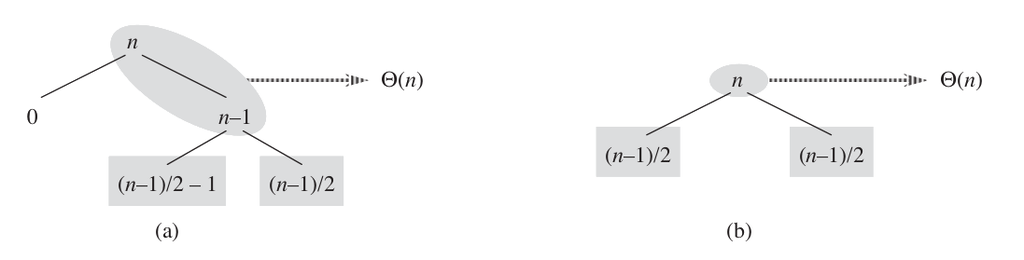

## Intuição para o Caso Médio

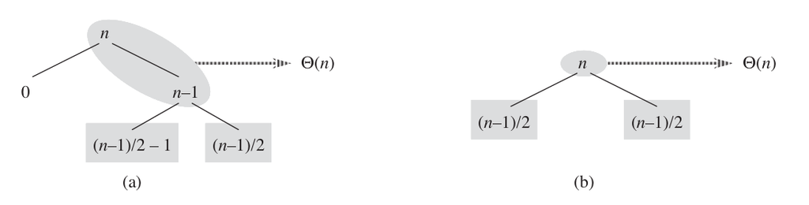

Intuitivamente, o custo do corte “ruim” é absorvido no custo $\Theta(n)$ do corte “bom”, resultando em um corte bom. Assim, o custo do `QUICKSORT`, quando os níveis alternam entre cortes “bons” e “ruins” é parecido com o custo envolvido quando há apenas cortes “bons”: $O(n \lg n)$, mas com uma constante maior, escondida na notação $O$.

## Bibliografia

[CRLS] CORMEN, T. H. et al. Algoritmos: Teoria e Prática. Elsevier, 2012. 3a Ed. Capítulo 7 (*QuickSort*), Seções 7.1 e 7.2.